# Tom Brady’s Passing Statistics

Dylan Lynch

## About Tom Brady

His career highlights include: 7× Super Bowl champion (XXXVI, XXXVIII, XXXIX, XLIX, LI, LIII, LV), 5× Super Bowl MVP (XXXVI, XXXVIII, XLIX, LI, LV), 3× NFL Most Valuable Player (2007, 2010, 2017), 2× NFL Offensive Player of the Year (2007, 2010), NFL Comeback Player of the Year (2009), 3× First-team All-Pro (2007, 2010, 2017), 3× Second-team All-Pro (2005, 2016, 2021), 15× Pro Bowl (2001, 2004, 2005, 2007, 2009–2018, 2021), 5× NFL passing touchdowns leader (2002, 2007, 2010, 2015, 2021), 4× NFL passing yards leader (2005, 2007, 2017, 2021), and 2× NFL passer rating leader (2007, 2010).

## Passing averages

Let’s see how many passing yards Tom Brady averaged in the regular and post season.

Regular season:

```r
mean(Brady_Regular_Career$Yds) #Average regular season yards
```

```
## [1] 3841.818
```

Post season:

```r
mean(Brady_Post_Career$Yds) #Average post season yards
```

```
## [1] 686.7895
```

Adjusted:

```r
mean(Brady_Regular_Career_Adj$Yds) #Average adjusted regular season yards (dropping two seasons)
```

```
## [1] 4221.9
```

Why are there three sets of numbers? `Brady_Regular_Career_Adj` drops the 2000 and 2008 seasons. Why? In 2000, Tom Brady was 1/3 for six yards due to being a backup, actually starting the season as the fourth string QB. In 2008, Tom Brady was 7/11 for 76 yards due to a season ending knee injury in the first quarter of the first game of the season. In 2016, Tom Brady was suspended for the first four games of the season due to the “Deflategate scandal”. However, we will include this season because they ended up winning the Super Bowl that year. Also, no adjustments were made to his post season career.

Next, we will do the same thing for touchdowns (TDs).

Regular season:

```r
mean(Brady_Regular_Career$TD) #Average regular season TD
```

```
## [1] 28.36364
```

Post season:

```r
mean(Brady_Post_Career$TD) #Average post season TD
```

```
## [1] 4.526316
```

Adjusted:

```r
mean(Brady_Regular_Career_Adj$TD) #Average adjusted regular season TD (dropping two seasons)
```

```
## [1] 31.2
```

## Unbreakable combined records?

Combined passing yards: (`Brady_Combined` includes all seasons including the post season)

```r
sum(Brady_Combined$Yds) #Total career passing yards
```

```
## [1] 97569
```

Combined TDs:

```r
sum(Brady_Combined$TD) #Total career passing TDs
```

```
## [1] 710
```

## Passing TDs by age

Did Tom Brady get better as he got older? Let’s take a look.

## 20s

Regular season:

```r
#Total regular season TDs 20s by age
aggregate(TD ~ Age, data=subset(Brady_Regular_Career, Age >=23 & Age<=29),sum)
```

```
##   Age TD
## 1  23  0
## 2  24 18
## 3  25 28
## 4  26 23
## 5  27 28
## 6  28 26
## 7  29 24
```

Post season:

```r
#Total post season TDs 20s by age
aggregate(TD ~ Age, data=subset(Brady_Post_Career, Age >=23 & Age<=29),sum)
```

```
##   Age TD
## 1  24  1
## 2  26  5
## 3  27  5
## 4  28  4
## 5  29  5
```

Combined:

```r
#Total TDs 20s by age
aggregate(TD ~ Age, data=subset(Brady_Combined, Age >=23 & Age<=29),sum)
```

```
##   Age TD
## 1  23  0
## 2  24 19
## 3  25 28
## 4  26 28
## 5  27 33
## 6  28 30
## 7  29 29
```

Total TDs in 20s:

```r
TD_20s <- aggregate(TD ~ Age, data=subset(Brady_Combined, Age >=23 & Age<=29),sum)
sum(TD_20s$TD)
```

```
## [1] 167
```

## 30s

Regular season:

```r
#Total regular season TD 30s
aggregate(TD ~ Age, data=subset(Brady_Regular_Career, Age >=30 & Age<=39),sum)
```

```
##    Age TD
## 1   30 50
## 2   31  0
## 3   32 28
## 4   33 36
## 5   34 39
## 6   35 34
## 7   36 25
## 8   37 33
## 9   38 36
## 10  39 28
```

Post season:

```r
#Total post season TD 30s
aggregate(TD ~ Age, data=subset(Brady_Post_Career, Age >=30 & Age<=39),sum)
```

```
##   Age TD
## 1  30  6
## 2  32  2
## 3  33  2
## 4  34  8
## 5  35  4
## 6  36  1
## 7  37 10
## 8  38  3
## 9  39  7
```

Combined:

```r
#Total TDs 30s
aggregate(TD ~ Age, data=subset(Brady_Combined, Age >=30 & Age<=39),sum)
```

```
##    Age TD
## 1   30 56
## 2   31  0
## 3   32 30
## 4   33 38
## 5   34 47
## 6   35 38
## 7   36 26
## 8   37 43
## 9   38 39
## 10  39 35
```

Total TDs 30s:

```r
TD_30s <- aggregate(TD ~ Age, data=subset(Brady_Combined, Age >=30 & Age<=39),sum)
sum(TD_30s$TD)
```

```
## [1] 352
```

## 40s

Regular season:

```r
#Total regular season TD 40s
aggregate(TD ~ Age, data=subset(Brady_Regular_Career, Age >=40),sum)
```

```
##   Age TD
## 1  40 32
## 2  41 29
## 3  42 24
## 4  43 40
## 5  44 43
```

Post season:

```r
#Total post season TD 40s
aggregate(TD ~ Age, data=subset(Brady_Post_Career, Age >=40),sum)
```

```
##   Age TD
## 1  40  8
## 2  41  2
## 3  42  0
## 4  43 10
## 5  44  3
```

Combined:

```r
#Total TDs 40s
aggregate(TD ~ Age, data=subset(Brady_Combined, Age >=40),sum)
```

```
##   Age TD
## 1  40 40
## 2  41 31
## 3  42 24
## 4  43 50
## 5  44 46
```

Total TDs 40s:

```r
TD_40s <- aggregate(TD ~ Age, data=subset(Brady_Combined, Age >=40),sum)
sum(TD_40s$TD)
```

```
## [1] 191
```

Well, he didn’t exactly play his entire 40s, but he did throw more TDs in his 40s than his 20s.

Numbers are great, but visualization tells the story.

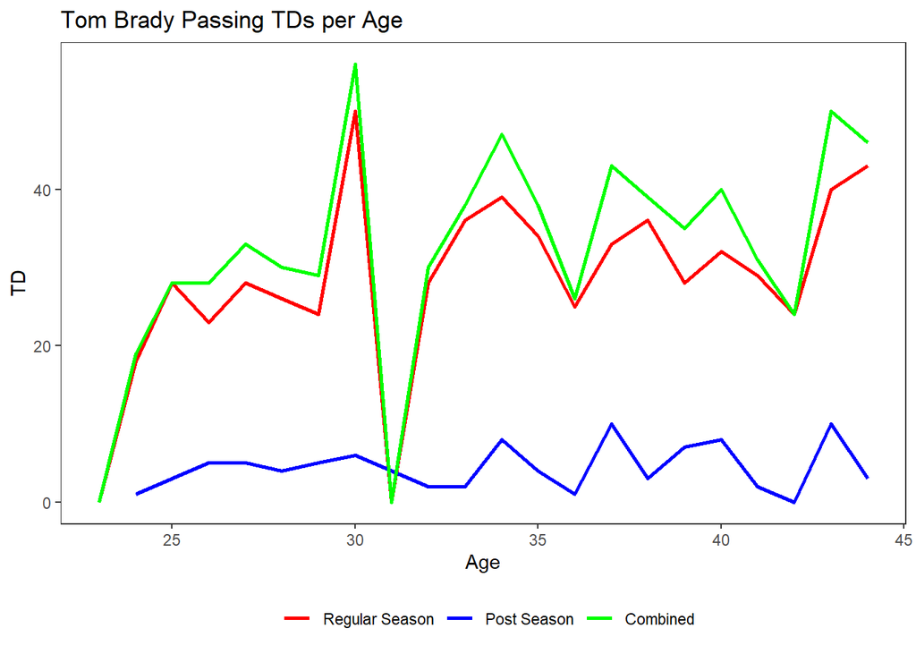

```r
#Passing touchdowns
Reg_TD <- subset(Brady_Regular_Career, select = c(Age, TD))
Post_TD <- subset(Brady_Post_Career, select = c(Age, TD))
Combined_TD <- aggregate(TD ~ Age, data=subset(Brady_Combined, select = c(Age, TD)),sum)

#TD plot
TD_plot <- ggplot()+
  geom_line(Reg_TD, mapping = aes(Age, TD, color = "red"), lwd = 1)+
  geom_line(Post_TD, mapping = aes(Age, TD, color = "blue"), lwd = 1)+
  geom_line(Combined_TD, mapping = aes(Age, TD, color = "green"), lwd = 1)+
  theme_bw()+
  theme(panel.grid.major = element_blank(), panel.grid.minor = element_blank())+
  scale_color_identity(name = "",
                       breaks = c("red", "blue", "green"),
                       labels = c("Regular Season", "Post Season", "Combined"),
                       guide = "legend")+
  theme(legend.position="bottom")+
  ggtitle("Tom Brady Passing TDs per Age")

TD_plot
```

How does this look? This is the plot without adjusting for the the 2000 and 2008 seasons.

Let’s try again with the adjusted data set.

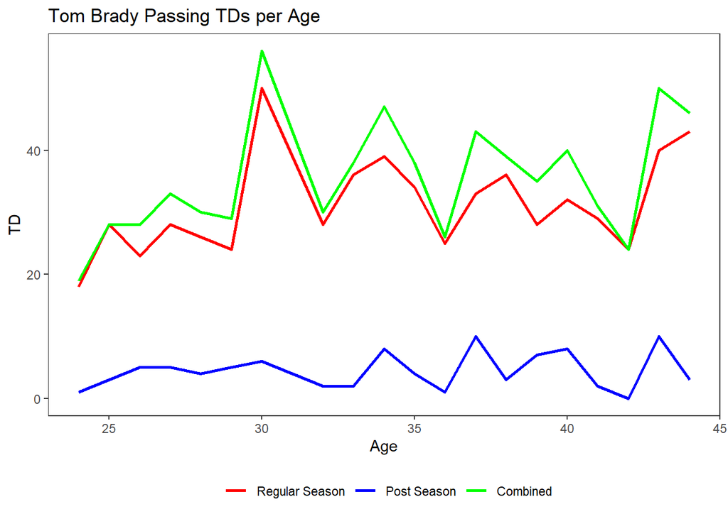

```r
#Adjusted TDs
Reg_TD_Adj <- subset(Brady_Regular_Career_Adj, select = c(Age, TD))
Combined_TD_Adj <- aggregate(TD ~ Age, data=subset(Brady_Combined_Adj, select = c(Age, TD)),sum)

#Adjusted TD plot
Adj_TD_plot <- ggplot()+
  geom_line(Reg_TD_Adj, mapping = aes(Age, TD, color = "red"), lwd = 1)+
  geom_line(Post_TD, mapping = aes(Age, TD, color = "blue"), lwd = 1)+
  geom_line(Combined_TD_Adj, mapping = aes(Age, TD, color = "green"), lwd = 1)+
  theme_bw()+
  theme(panel.grid.major = element_blank(), panel.grid.minor = element_blank())+
  scale_color_identity(name = "",
                       breaks = c("red", "blue", "green"),
                       labels = c("Regular Season", "Post Season", "Combined"),
                       guide = "legend")+
  theme(legend.position="bottom")+
  ggtitle("Tom Brady Passing TDs per Age")

Adj_TD_plot
```

See the difference?

Check out the GIF!

[figure not shown]

```r
knitr::include_graphics("AdjTDplot.gif")
```

## Passing yards by age

Now, we can do the same for passing yards. Let’s take a look.

## 20s

Regular season:

```r
#Total regular season yards 20s
aggregate(Yds ~ Age, data=subset(Brady_Regular_Career, Age >=23 & Age<=29),sum)
```

```
##   Age  Yds
## 1  23    6
## 2  24 2843
## 3  25 3764
## 4  26 3620
## 5  27 3692
## 6  28 4110
## 7  29 3529
```

Post season:

```r
#Total post season yards 20s
aggregate(Yds ~ Age, data=subset(Brady_Post_Career, Age >=23 & Age<=29),sum)
```

```
##   Age Yds
## 1  24 572
## 2  26 792
## 3  27 587
## 4  28 542
## 5  29 724
```

Combined:

```r
#Total yards 20s
aggregate(Yds ~ Age, data=subset(Brady_Combined, Age >=23 & Age<=29),sum)
```

```
##   Age  Yds
## 1  23    6
## 2  24 3415
## 3  25 3764
## 4  26 4412
## 5  27 4279
## 6  28 4652
## 7  29 4253
```

Total yards in 20s:

```r
Yds_20s <- aggregate(Yds ~ Age, data=subset(Brady_Combined, Age >=23 & Age<=29),sum)
sum(Yds_20s$Yds)
```

```
## [1] 24781
```

## 30s

Regular season:

```r
#Total regular season yards 30s
aggregate(Yds ~ Age, data=subset(Brady_Regular_Career, Age >=30 & Age<=39),sum)
```

```
##    Age  Yds
## 1   30 4806
## 2   31   76
## 3   32 4398
## 4   33 3900
## 5   34 5235
## 6   35 4827
## 7   36 4343
## 8   37 4109
## 9   38 4770
## 10  39 3554
```

Post season:

```r
#Total post season yards 30s
aggregate(Yds ~ Age, data=subset(Brady_Post_Career, Age >=30 & Age<=39),sum)
```

```
##   Age  Yds
## 1  30  737
## 2  32  154
## 3  33  299
## 4  34  878
## 5  35  664
## 6  36  475
## 7  37  921
## 8  38  612
## 9  39 1137
```

Combined:

```r
#Total yards 30s
aggregate(Yds ~ Age, data=subset(Brady_Combined, Age >=30 & Age<=39),sum)
```

```
##    Age  Yds
## 1   30 5543
## 2   31   76
## 3   32 4552
## 4   33 4199
## 5   34 6113
## 6   35 5491
## 7   36 4818
## 8   37 5030
## 9   38 5382
## 10  39 4691
```

Total yards in 30s:

```r
Yds_30s <- aggregate(Yds ~ Age, data=subset(Brady_Combined, Age >=30 & Age<=39),sum)
sum(Yds_30s$Yds)
```

```
## [1] 45895
```

## 40s

Regular season:

```r
#Total regular season yards 40s
aggregate(Yds ~ Age, data=subset(Brady_Regular_Career, Age >=40),sum)
```

```
##   Age  Yds
## 1  40 4577
## 2  41 4355
## 3  42 4057
## 4  43 4633
## 5  44 5316
```

Post season:

```r
#Total post season yards 40s
aggregate(Yds ~ Age, data=subset(Brady_Post_Career, Age >=40),sum)
```

```
##   Age  Yds
## 1  40 1132
## 2  41  953
## 3  42  209
## 4  43 1061
## 5  44  600
```

Combined:

```r
#Total total yards 40s
aggregate(Yds ~ Age, data=subset(Brady_Combined, Age >=40),sum)
```

```
##   Age  Yds
## 1  40 5709
## 2  41 5308
## 3  42 4266
## 4  43 5694
## 5  44 5916
```

Total yards in 40s:

```r
Yds_40s <- aggregate(Yds ~ Age, data=subset(Brady_Combined, Age >=40),sum)
sum(Yds_40s$Yds)
```

```
## [1] 26893
```

Once again, he didn’t exactly play his entire 40s, but he did throw more yards in his 40s than his 20s.

Let’s recreate the visualization with passing yards this time.

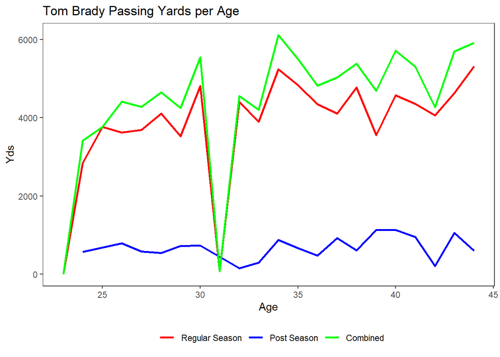

```r
#Passing yards
Reg_Yards <- subset(Brady_Regular_Career, select = c(Age, Yds))
Post_Yards <- subset(Brady_Post_Career, select = c(Age, Yds))
Combined <- aggregate(Yds ~ Age, data=subset(Brady_Combined, select = c(Age, Yds)),sum)

#Yards plot
Yds_plot <- ggplot()+
  geom_line(Reg_Yards, mapping = aes(Age, Yds, color = "red"), lwd = 1)+
  geom_line(Post_Yards, mapping = aes(Age, Yds, color = "blue"), lwd = 1)+
  geom_line(Combined, mapping = aes(Age, Yds, color = "green"), lwd = 1)+
  theme_bw()+
  theme(panel.grid.major = element_blank(), panel.grid.minor = element_blank())+
  scale_color_identity(name = "",
                       breaks = c("red", "blue", "green"),
                       labels = c("Regular Season", "Post Season", "Combined"),
                       guide = "legend")+
  theme(legend.position="bottom")+
  ggtitle("Tom Brady Passing Yards per Age")


Yds_plot
```

Again, we need to adjust for the the 2000 and 2008 seasons.

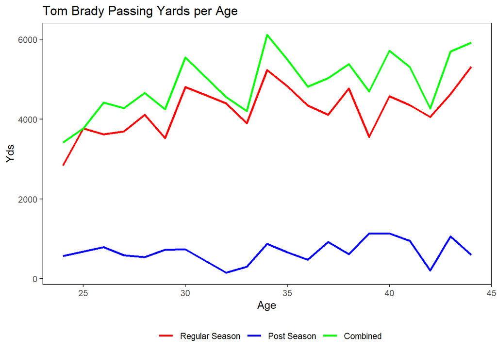

```r
#Adjusted yards
Reg_Yards_Adj <- subset(Brady_Regular_Career_Adj, select = c(Age, Yds))
Combined_Yards_Adj <- aggregate(Yds ~ Age, data=subset(Brady_Combined_Adj, select = c(Age, Yds)),sum)

#Adjusted yards plot
Adj_Yds_plot <- ggplot()+
  geom_line(Reg_Yards_Adj, mapping = aes(Age, Yds, color = "red"), lwd = 1)+
  geom_line(Post_Yards, mapping = aes(Age, Yds, color = "blue"), lwd = 1)+
  geom_line(Combined_Yards_Adj, mapping = aes(Age, Yds, color = "green"), lwd = 1)+
  theme_bw()+
  theme(panel.grid.major = element_blank(), panel.grid.minor = element_blank())+
  scale_color_identity(name = "",
                       breaks = c("red", "blue", "green"),
                       labels = c("Regular Season", "Post Season", "Combined"),
                       guide = "legend")+
  theme(legend.position="bottom")+
  ggtitle("Tom Brady Passing Yards per Age")

Adj_Yds_plot
```

Check out the GIF!

[figure not shown]

```r
knitr::include_graphics("AdjYdsplot.gif")
```